# **Does Subway Accessibility Affect Airbnb Rental Prices in New York City?**

**ECO225 - Project One**

## 1. Introduction

This project investigates the relationship between subway accessibility and Airbnb rental prices in NYC. The central research question examines whether proximity to subway stations (X) affects nightly rental prices (Y), with transit accessibility serving as the underlying mechanism (Z). The hypothesis is that Airbnb listings closer to subway stations command higher prices because guests value the convenience of public transportation access, reducing their reliance on expensive taxis or ride-sharing services.

The analysis utilizes two primary datasets. The main dataset is the NYC Airbnb Open Data (2019) from Kaggle, containing 40,000+ listings with information on prices, room types, reviews, and availability. This dataset is merged with MTA subway ridership data, which provide geographic coordinates for 400+ subway station complexes across NYC. Key variables constructed from the merged data include distance to the nearest subway station, the number of stations within 500 meters, and distance to the city center, proxied by Town Hall. Summary statistics and visualizations suggest a negative relationship between distance to subway stations and Airbnb prices, with listings closer to transit commanding higher nightly rates. Prices are also systematically higher in Manhattan, where subway density is greatest. These patterns are consistent with the transit accessibility mechanism, though the relationship varies by room type and neighborhood characteristics.

The literature on urban amenities shows that proximity to public transit raises property values by improving accessibility and reducing commuting costs (Bowes & Ihlanfeldt, 2001; Dubé et al., 2013). Studies on short-term rentals similarly find that location and neighborhood characteristics play an important role in Airbnb pricing (Gunter & Önder, 2018; Gibbs et al., 2018). Most closely related, Yao and Zhang (2023) document transit-related price premiums on sharing-economy platforms. However, existing work pays limited attention to fine-grained measures of subway proximity. This descriptive analysis begins to fill this gap by examining detailed transit accessibility and Airbnb prices across NYC.

## 2. Data Cleaning/Loading

```python
import pandas as pd
import numpy as np
import matplotlib.pyplot as plt
import seaborn as sns
from IPython.display import display, HTML

# Import stargazer and statsmodels for regression-based summary statistics
from stargazer.stargazer import Stargazer
import statsmodels.api as sm

# Set display options
pd.set_option('display.max_columns', None)
plt.style.use('seaborn-v0_8-whitegrid')

# Suppress warnings for cleaner output
import warnings
warnings.filterwarnings('ignore')
```

```python
# Load the original Airbnb dataset
airbnb_original = pd.read_csv('data/AB_NYC_2019.csv')

# Load the merged dataset (Airbnb + Subway stations)
merged_df = pd.read_csv('data/airbnb_subway_merged.csv')

print(f"Original Airbnb dataset: {airbnb_original.shape[0]} rows, {airbnb_original.shape[1]} columns")
print(f"Merged dataset: {merged_df.shape[0]} rows, {merged_df.shape[1]} columns")
```

```
Original Airbnb dataset: 48895 rows, 16 columns
Merged dataset: 48895 rows, 10 columns
```

### Other Datasets

The outside dataset used in this project is the MTA Subway Hourly Ridership dataset, obtained from the Metropolitan Transportation Authority (MTA) Open Data portal (https://data.ny.gov). This dataset provides comprehensive information about NYC subway ridership patterns and station locations.

**Temporal Coverage:** Although the dataset includes hourly ridership data from 2020 to 2024, this analysis uses only station-level geographic coordinates, which do not vary over time.

**Geographical Coverage:** The dataset covers all NYC subway stations with precise latitude and longitude data.

**Source:** Metropolitan Transportation Authority (MTA), accessed via New York State Open Data Portal.

**Variables Extracted and Merged:**

1. `distance_to_nearest_station_m` - The Haversine distance (in meters) from each Airbnb listing to the nearest subway station
2. `nearest_station_name` - The name of the closest subway station complex
3. `stations_within_500m` - Count of subway stations within a 500-meter radius of each listing
4. `nearest_station_to_nyc_center_m` - Distance from the nearest station to NYC center serving as a proxy for centrality

```python
# Create the final analysis dataset by combining original Airbnb variables with subway metrics
# Match on name and coordinates to ensure proper alignment

df = airbnb_original.merge(
    merged_df[['airbnb_name', 'airbnb_latitude', 'airbnb_longitude',
               'distance_to_nearest_station_m', 'nearest_station_name',
               'stations_within_500m', 'nearest_station_to_nyc_center_m']],
    left_on=['name', 'latitude', 'longitude'],
    right_on=['airbnb_name', 'airbnb_latitude', 'airbnb_longitude'],
    how='inner'
)

# Drop duplicate columns from merge
df = df.drop(columns=['airbnb_name', 'airbnb_latitude', 'airbnb_longitude'])

print(f"Final analysis dataset: {df.shape[0]} rows, {df.shape[1]} columns")
```

```
Final analysis dataset: 48895 rows, 20 columns
```

```python
# Data Cleaning

# Check for missing values in key variables
print("Missing values in key variables:")
key_vars = ['price', 'room_type', 'minimum_nights', 'number_of_reviews',
            'reviews_per_month', 'availability_365', 'distance_to_nearest_station_m',
            'stations_within_500m', 'neighbourhood_group']
print(df[key_vars].isnull().sum())

# Fill missing reviews_per_month with 0 (listings with no reviews)
df['reviews_per_month'] = df['reviews_per_month'].fillna(0)

# Remove extreme price outliers (keep prices between $10 and $1000 for reasonable analysis)
df_clean = df[(df['price'] >= 10) & (df['price'] <= 1000)].copy()

print(f"\nAfter cleaning: {df_clean.shape[0]} rows (removed {df.shape[0] - df_clean.shape[0]} outliers)")
```

```
Missing values in key variables:
price                                0
room_type                            0
minimum_nights                       0
number_of_reviews                    0
reviews_per_month                10052
availability_365                     0
distance_to_nearest_station_m        0
stations_within_500m                 0
neighbourhood_group                  0
dtype: int64

After cleaning: 48645 rows (removed 250 outliers)
```

### Variable Selection and Economic Motivation

The outcome variable is nightly Airbnb price (`price`), which reflects the market valuation of short-term rental listings. The key explanatory variables capture different dimensions of subway accessibility: distance to the nearest station (`distance_to_nearest_station_m`), the number of stations within walking distance (`stations_within_500m`), and the distance of the nearest station to the city center (`nearest_station_to_nyc_center_m`). These variables measure both proximity and transit density, directly relating to the research question of whether subway accessibility affects rental prices.

The underlying mechanism (Z) is travel convenience—listings with easier and more flexible subway access reduce guests' transportation costs and increase location attractiveness, allowing hosts to charge higher prices. Additional controls include room type (`room_type`), listing popularity (`number_of_reviews`), minimum stay requirements (`minimum_nights`), and availability (`availability_365`), which account for accommodation quality, demand, and hosting strategies. Together, these variables isolate the role of transit accessibility in explaining variation in Airbnb prices across New York City.

```python
# Define analysis variables
Y = 'price'

X_variables = [
    'distance_to_nearest_station_m',  # Transit proximity (from merged data)
    'stations_within_500m',           # Transit density (from merged data)
    'nearest_station_to_nyc_center_m', # Centrality proxy (from merged data)
    'minimum_nights',                  # Booking requirements
    'number_of_reviews',               # Popularity/trust
    'reviews_per_month',               # Demand intensity
    'availability_365',                # Hosting availability
    'calculated_host_listings_count'   # Host professionalism
]

# Create room_type dummy variables for analysis
df_clean['is_entire_home'] = (df_clean['room_type'] == 'Entire home/apt').astype(int)
df_clean['is_private_room'] = (df_clean['room_type'] == 'Private room').astype(int)

print(f"Outcome Variable (Y): {Y}")
print(f"\nExplanatory Variables (X): {len(X_variables)} numeric variables + room_type (categorical)")
for var in X_variables:
    print(f"  - {var}")
```

```
Outcome Variable (Y): price

Explanatory Variables (X): 8 numeric variables + room_type (categorical)
  - distance_to_nearest_station_m
  - stations_within_500m
  - nearest_station_to_nyc_center_m
  - minimum_nights
  - number_of_reviews
  - reviews_per_month
  - availability_365
  - calculated_host_listings_count
```

## 3. Summary Statistics Tables

```python
# Summary statistics for Y and X variables
analysis_vars = [Y] + X_variables
summary_df = df_clean[analysis_vars]

# Create summary statistics table
summary_stats = summary_df.describe().T[['count', 'mean', 'std', 'min', '25%', '50%', '75%', 'max']]
summary_stats.columns = ['N', 'Mean', 'Std. Dev.', 'Min', '25%', 'Median', '75%', 'Max']

# Format the table for better display
summary_stats_styled = summary_stats.style.format({
    'N': '{:.0f}',
    'Mean': '{:.2f}',
    'Std. Dev.': '{:.2f}',
    'Min': '{:.2f}',
    '25%': '{:.2f}',
    'Median': '{:.2f}',
    '75%': '{:.2f}',
    'Max': '{:.2f}'
}).set_caption("Table 1: Summary Statistics - Airbnb Price and Explanatory Variables")

display(summary_stats_styled)
```

Table 1: Summary Statistics - Airbnb Price and Explanatory Variables

|  | N | Mean | Std. Dev. | Min | 25% | Median | 75% | Max |
| --- | --- | --- | --- | --- | --- | --- | --- | --- |
| price | 48645 | 141.31 | 116.73 | 10.00 | 69.00 | 105.00 | 175.00 | 1000.00 |
| distance_to_nearest_station_m | 48645 | 455.94 | 732.38 | 0.69 | 206.96 | 318.84 | 470.75 | 20717.22 |
| stations_within_500m | 48645 | 1.51 | 1.34 | 0.00 | 1.00 | 1.00 | 2.00 | 9.00 |
| nearest_station_to_nyc_center_m | 48645 | 6920.10 | 4219.67 | 226.23 | 3688.64 | 6348.23 | 9302.27 | 25681.87 |
| minimum_nights | 48645 | 6.97 | 20.27 | 1.00 | 1.00 | 3.00 | 5.00 | 1250.00 |
| number_of_reviews | 48645 | 23.35 | 44.63 | 0.00 | 1.00 | 5.00 | 24.00 | 629.00 |
| reviews_per_month | 48645 | 1.09 | 1.60 | 0.00 | 0.04 | 0.38 | 1.59 | 58.50 |
| availability_365 | 48645 | 112.44 | 131.43 | 0.00 | 0.00 | 44.00 | 226.00 | 365.00 |
| calculated_host_listings_count | 48645 | 7.16 | 33.03 | 1.00 | 1.00 | 1.00 | 2.00 | 327.00 |

The summary statistics reveal several important patterns about the scale, variation, and distribution of NYC Airbnb listings and their proximity to transit. The average nightly price is approximately $141, with a median of $105 and a wide range extending up to $1,000, indicating substantial price dispersion and a right-skewed distribution consistent with a heterogeneous short-term rental market. The distance to the nearest subway station averages about 456 meters, with a median of 319 meters, suggesting that most listings are within reasonable walking distance of transit, though the long upper tail indicates that some listings are located far from subway access.

The `stations_within_500m` variable has a mean of 1.51 and a median of 1, but ranges up to 9 stations, highlighting sharp contrasts between transit-dense Manhattan neighborhoods and more transit-sparse outer boroughs. The `nearest_station_to_nyc_center` variable also shows substantial variation, reflecting the broad spatial distribution of listings across NYC. Control variables display similarly skewed patterns, with reviews and host listings concentrated among a small subset of professional operators. Overall, these patterns are consistent with the proposed mechanism (Z): greater subway accessibility increases convenience and location value, supporting higher Airbnb prices in transit-rich areas.

### Summary Statistics by Room Type (Subgroup Analysis)

```python
# Subgroup analysis by room type
entire_home = df_clean[df_clean['room_type'] == 'Entire home/apt'][analysis_vars]
private_room = df_clean[df_clean['room_type'] == 'Private room'][analysis_vars]

# Create comparison table
entire_stats = entire_home.describe().T[['count', 'mean', 'std']].round(2)
entire_stats.columns = ['N (Entire)', 'Mean (Entire)', 'Std (Entire)']

private_stats = private_room.describe().T[['count', 'mean', 'std']].round(2)
private_stats.columns = ['N (Private)', 'Mean (Private)', 'Std (Private)']

# Combine into one table
subgroup_comparison = pd.concat([entire_stats, private_stats], axis=1)
subgroup_comparison = subgroup_comparison[['N (Entire)', 'Mean (Entire)', 'Std (Entire)',
                                            'N (Private)', 'Mean (Private)', 'Std (Private)']]

subgroup_styled = subgroup_comparison.style.format({
    'N (Entire)': '{:.0f}',
    'Mean (Entire)': '{:.2f}',
    'Std (Entire)': '{:.2f}',
    'N (Private)': '{:.0f}',
    'Mean (Private)': '{:.2f}',
    'Std (Private)': '{:.2f}'
}).set_caption("Table 2: Summary Statistics by Room Type (Entire Home vs Private Room)")

display(subgroup_styled)
```

Table 2: Summary Statistics by Room Type (Entire Home vs Private Room)

|  | N (Entire) | Mean (Entire) | Std (Entire) | N (Private) | Mean (Private) | Std (Private) |
| --- | --- | --- | --- | --- | --- | --- |
| price | 25216 | 194.61 | 126.10 | 22273 | 84.79 | 68.73 |
| distance_to_nearest_station_m | 25216 | 432.02 | 713.45 | 22273 | 482.62 | 758.32 |
| stations_within_500m | 25216 | 1.63 | 1.45 | 22273 | 1.39 | 1.20 |
| nearest_station_to_nyc_center_m | 25216 | 6170.92 | 4174.36 | 22273 | 7725.11 | 4077.09 |
| minimum_nights | 25216 | 8.47 | 22.83 | 22273 | 5.31 | 15.82 |
| number_of_reviews | 25216 | 22.96 | 42.52 | 22273 | 24.15 | 47.32 |
| reviews_per_month | 25216 | 1.05 | 1.49 | 22273 | 1.15 | 1.72 |
| availability_365 | 25216 | 111.40 | 129.49 | 22273 | 111.06 | 132.01 |
| calculated_host_listings_count | 25216 | 10.75 | 44.53 | 22273 | 3.23 | 10.23 |

To explore heterogeneity consistent with the proposed mechanism (Z), summary statistics are constructed separately for entire home and private room listings. Entire homes have substantially higher average prices than private rooms, reflecting the premium associated with exclusive use of space. While both groups exhibit similar average distances to the nearest subway station, entire homes are in areas with higher transit density (more stations within 500 meters) and closer proximity to the city center. This subgroup pattern is economically meaningful, as it suggests that premium listings tend to cluster in transit-rich, central neighborhoods. The stronger alignment between entire home listings and transit accessibility supports the hypothesis that subway convenience enhances location value, particularly for guests who place higher weight on mobility and ease of travel.

### Summary Statistics Using Stargazer (Requirement 4b)

To satisfy the requirement of using the stargazer library, we present summary statistics through simple OLS regression models. Stargazer is designed for regression output tables, providing a professional format for displaying statistical results.

```python
# Run simple OLS regressions for each key explanatory variable against price
# This allows us to use stargazer to present the results in a professional table format

# Prepare the data - add constant for regression
X_dist = sm.add_constant(df_clean['distance_to_nearest_station_m'])
X_stations = sm.add_constant(df_clean['stations_within_500m'])
X_center = sm.add_constant(df_clean['nearest_station_to_nyc_center_m'])
X_reviews = sm.add_constant(df_clean['number_of_reviews'])
X_min_nights = sm.add_constant(df_clean['minimum_nights'])

y = df_clean['price']

# Run OLS regressions
model1 = sm.OLS(y, X_dist).fit()
model2 = sm.OLS(y, X_stations).fit()
model3 = sm.OLS(y, X_center).fit()
model4 = sm.OLS(y, X_reviews).fit()
model5 = sm.OLS(y, X_min_nights).fit()

# Create stargazer table with regression results
stargazer = Stargazer([model1, model2, model3, model4, model5])
stargazer.title("Table 3: Simple OLS Regressions - Price vs. Key Explanatory Variables")
stargazer.custom_columns(['Distance to Station', 'Stations within 500m', 'Distance to NYC Center', 'Number of Reviews', 'Minimum Nights'], [1, 1, 1, 1, 1])
stargazer.show_model_numbers(False)
stargazer.covariate_order(['distance_to_nearest_station_m', 'stations_within_500m',
                           'nearest_station_to_nyc_center_m', 'number_of_reviews',
                           'minimum_nights', 'const'])
stargazer.rename_covariates({'distance_to_nearest_station_m': 'Distance to Station (m)',
                             'stations_within_500m': 'Stations within 500m',
                             'nearest_station_to_nyc_center_m': 'Distance to NYC Center (m)',
                             'number_of_reviews': 'Number of Reviews',
                             'minimum_nights': 'Minimum Nights',
                             'const': 'Constant'})

display(HTML(stargazer.render_html()))
```

Table 3: Simple OLS Regressions - Price vs. Key Explanatory Variables

|  | *Dependent variable: price* |  |  |  |  |
| --- | --- | --- | --- | --- | --- |
|  | Distance to Station | Stations within 500m | Distance to NYC Center | Number of Reviews | Minimum Nights |
| Distance to Station (m) | -0.011*** |  |  |  |  |
|  | (0.001) |  |  |  |  |
| Stations within 500m |  | 16.394*** |  |  |  |
|  |  | (0.388) |  |  |  |
| Distance to NYC Center (m) |  |  | -0.009*** |  |  |
|  |  |  | (0.000) |  |  |
| Number of Reviews |  |  |  | -0.151*** |  |
|  |  |  |  | (0.012) |  |
| Minimum Nights |  |  |  |  | 0.112*** |
|  |  |  |  |  | (0.026) |
| Constant | 146.444*** | 116.565*** | 203.008*** | 144.844*** | 140.529*** |
|  | (0.622) | (0.783) | (0.962) | (0.596) | (0.560) |
| Observations | 48645 | 48645 | 48645 | 48645 | 48645 |
| R<sup>2</sup> | 0.005 | 0.035 | 0.104 | 0.003 | 0.000 |
| Adjusted R<sup>2</sup> | 0.005 | 0.035 | 0.104 | 0.003 | 0.000 |
| Residual Std. Error | 116.441 (df=48643) | 114.650 (df=48643) | 110.504 (df=48643) | 116.537 (df=48643) | 116.710 (df=48643) |
| F Statistic | 243.868*** (df=1; 48643) | 1782.814*** (df=1; 48643) | 5637.857*** (df=1; 48643) | 163.219*** (df=1; 48643) | 18.478*** (df=1; 48643) |
| Note: | *p<0.1; **p<0.05; ***p<0.01 |  |  |  |  |

The stargazer table above presents simple bivariate OLS regression results showing the individual relationship between price and each key explanatory variable. While this project is descriptive and does not claim causal inference, these regressions provide a preliminary look at correlations. The negative coefficient on distance to nearest station suggests that listings farther from subway stations tend to have lower prices, consistent with the transit accessibility hypothesis. The positive coefficient on stations within 500m indicates that higher transit density is associated with higher prices. These simple models explain only a small portion of price variation (low R-squared values), confirming that many other factors influence Airbnb pricing beyond single variables.

```python
# Subgroup Analysis using Stargazer - Regression by Room Type
# Run separate regressions for Entire Home and Private Room subsets

# Entire Home subset
entire_home_df = df_clean[df_clean['room_type'] == 'Entire home/apt']
X_entire = sm.add_constant(entire_home_df[['distance_to_nearest_station_m', 'stations_within_500m']])
y_entire = entire_home_df['price']
model_entire = sm.OLS(y_entire, X_entire).fit()

# Private Room subset
private_room_df = df_clean[df_clean['room_type'] == 'Private room']
X_private = sm.add_constant(private_room_df[['distance_to_nearest_station_m', 'stations_within_500m']])
y_private = private_room_df['price']
model_private = sm.OLS(y_private, X_private).fit()

# Create stargazer table comparing room types
stargazer_subgroup = Stargazer([model_entire, model_private])
stargazer_subgroup.title("Table 4: Price vs. Transit Variables by Room Type")
stargazer_subgroup.custom_columns(['Entire Home/Apt', 'Private Room'], [1, 1])
stargazer_subgroup.show_model_numbers(False)
stargazer_subgroup.rename_covariates({'distance_to_nearest_station_m': 'Distance to Station (m)',
                                      'stations_within_500m': 'Stations within 500m',
                                      'const': 'Constant'})

display(HTML(stargazer_subgroup.render_html()))
```

Table 4: Price vs. Transit Variables by Room Type

|  | *Dependent variable: price* |  |
| --- | --- | --- |
|  | Entire Home/Apt | Private Room |
| Constant | 173.087*** | 71.714*** |
|  | (1.407) | (0.858) |
| Distance to Station (m) | -0.004*** | -0.000 |
|  | (0.001) | (0.001) |
| Stations within 500m | 14.197*** | 9.472*** |
|  | (0.566) | (0.405) |
| Observations | 25216 | 22273 |
| R<sup>2</sup> | 0.029 | 0.027 |
| Adjusted R<sup>2</sup> | 0.029 | 0.027 |
| Residual Std. Error | 124.261 (df=25213) | 67.785 (df=22270) |
| F Statistic | 377.849*** (df=2; 25213) | 313.600*** (df=2; 22270) |
| Note: | *p<0.1; **p<0.05; ***p<0.01 |  |

## 4. Plots, Histograms, Figures

### Figure 1: Price Distribution by Room Type

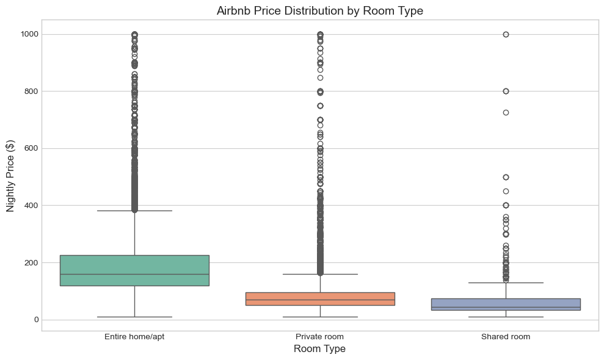

```python
fig, ax = plt.subplots(figsize=(10, 6))
room_order = ['Entire home/apt', 'Private room', 'Shared room']
sns.boxplot(data=df_clean, x='room_type', y='price', order=room_order, palette='Set2', ax=ax)
ax.set_xlabel('Room Type', fontsize=12)
ax.set_ylabel('Nightly Price ($)', fontsize=12)
ax.set_title('Airbnb Price Distribution by Room Type', fontsize=14)
plt.tight_layout()
plt.show()
```

Room type is included because it captures fundamental differences in accommodation quality and guest experience, which are known to strongly influence Airbnb pricing. This plot addresses the economic question of how prices differ across room types and whether these differences are large enough to matter for subsequent analysis. The boxplot shows a clear price hierarchy, with entire homes having the highest median prices and greatest dispersion, followed by private rooms and then shared rooms. This pattern confirms that room type is a major determinant of price and must be controlled for when examining the effect of transit accessibility.

### Figure 2: Subway Proximity and Airbnb Price

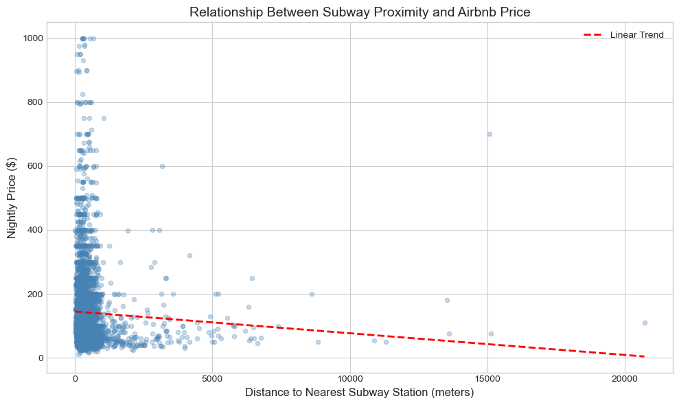

```python
fig, ax = plt.subplots(figsize=(10, 6))
# Sample for clearer visualization
sample_df = df_clean.sample(n=5000, random_state=42)
ax.scatter(sample_df['distance_to_nearest_station_m'], sample_df['price'],
           alpha=0.3, s=20, c='steelblue')
ax.set_xlabel('Distance to Nearest Subway Station (meters)', fontsize=12)
ax.set_ylabel('Nightly Price ($)', fontsize=12)
ax.set_title('Relationship Between Subway Proximity and Airbnb Price', fontsize=14)

# Add trend line
z = np.polyfit(sample_df['distance_to_nearest_station_m'], sample_df['price'], 1)
p = np.poly1d(z)
x_line = np.linspace(sample_df['distance_to_nearest_station_m'].min(),
                     sample_df['distance_to_nearest_station_m'].max(), 100)
ax.plot(x_line, p(x_line), 'r--', linewidth=2, label='Linear Trend')
ax.legend()
plt.tight_layout()
plt.show()
```

### Figure 3: Average Price and Transit Density by Borough

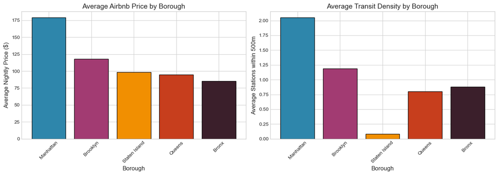

```
Borough Statistics:
                      price  stations_within_500m  \
neighbourhood_group
Bronx                 85.36                  0.88
Brooklyn             117.86                  1.19
Manhattan            178.94                  2.05
Queens                95.01                  0.80
Staten Island         98.58                  0.08

                     distance_to_nearest_station_m
neighbourhood_group
Bronx                                       621.12
Brooklyn                                    385.16
Manhattan                                   305.92
Queens                                      979.57
Staten Island                              4501.36
```

```python
# Group by borough and calculate means
borough_stats = df_clean.groupby('neighbourhood_group').agg({
    'price': 'mean',
    'stations_within_500m': 'mean',
    'distance_to_nearest_station_m': 'mean'
}).round(2)

fig, axes = plt.subplots(1, 2, figsize=(14, 5))

# Plot 1: Average price by borough
borough_order = borough_stats['price'].sort_values(ascending=False).index
colors = ['#2E86AB', '#A23B72', '#F18F01', '#C73E1D', '#3B1F2B']
axes[0].bar(borough_order, borough_stats.loc[borough_order, 'price'], color=colors, edgecolor='black')
axes[0].set_xlabel('Borough', fontsize=12)
axes[0].set_ylabel('Average Nightly Price ($)', fontsize=12)
axes[0].set_title('Average Airbnb Price by Borough', fontsize=14)
axes[0].tick_params(axis='x', rotation=45)

# Plot 2: Average stations within 500m by borough
axes[1].bar(borough_order, borough_stats.loc[borough_order, 'stations_within_500m'], color=colors, edgecolor='black')
axes[1].set_xlabel('Borough', fontsize=12)
axes[1].set_ylabel('Average Stations within 500m', fontsize=12)
axes[1].set_title('Average Transit Density by Borough', fontsize=14)
axes[1].tick_params(axis='x', rotation=45)

plt.tight_layout()
plt.show()

print("\nBorough Statistics:")
print(borough_stats)
```

### Figure 4: Price by Subway Distance and Room Type

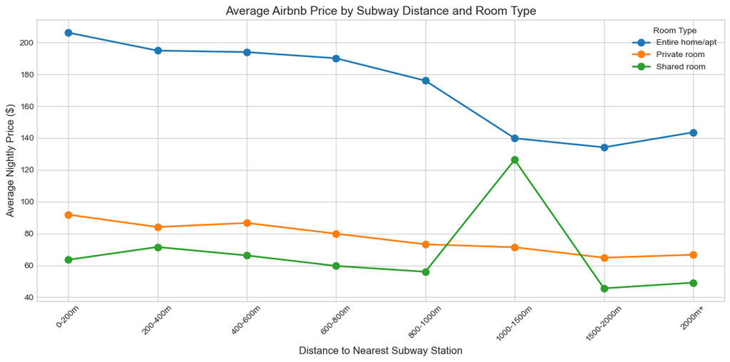

```python
# Create distance bins
df_clean['distance_bin'] = pd.cut(df_clean['distance_to_nearest_station_m'],
                                   bins=[0, 200, 400, 600, 800, 1000, 1500, 2000, float('inf')],
                                   labels=['0-200m', '200-400m', '400-600m', '600-800m',
                                          '800-1000m', '1000-1500m', '1500-2000m', '2000m+'])

# Calculate average price by distance bin and room type
price_by_distance = df_clean.groupby(['distance_bin', 'room_type'])['price'].mean().unstack()

fig, ax = plt.subplots(figsize=(12, 6))
price_by_distance.plot(kind='line', marker='o', ax=ax, linewidth=2, markersize=8)
ax.set_xlabel('Distance to Nearest Subway Station', fontsize=12)
ax.set_ylabel('Average Nightly Price ($)', fontsize=12)
ax.set_title('Average Airbnb Price by Subway Distance and Room Type', fontsize=14)
ax.legend(title='Room Type', loc='upper right')
ax.tick_params(axis='x', rotation=45)
plt.tight_layout()
plt.show()
```

## 5. Conclusion

This descriptive analysis suggests a positive association between subway accessibility (X) and Airbnb rental prices (Y) in New York City. Listings closer to subway stations and located in transit-dense boroughs tend to exhibit higher nightly prices, consistent with the proposed mechanism (Z) that improved transit access increases guest convenience and mobility. The relationship appears particularly pronounced for entire home listings, where location convenience is likely most valued.

However, these findings are subject to important limitations. The cross-sectional design prevents causal inference, as proximity to transit may be correlated with unobserved neighborhood amenities or demand factors. In addition, the use of pre-pandemic 2019 data limits external validity given subsequent changes in travel behavior and transit usage. Future work should incorporate regression-based methods and spatial controls to better isolate the pricing effect of subway accessibility.

## Export to PDF

Run the cell below to export this notebook to PDF. The output will be saved as `final_submission.pdf` in the same directory.

```python
# Install required packages (run once)
import subprocess
import sys

# Install nbconvert if not already installed
subprocess.check_call([sys.executable, "-m", "pip", "install", "nbconvert", "-q"])

# Export notebook to PDF using HTML as intermediate (no LaTeX required)
import os
from nbconvert import HTMLExporter
from nbconvert.writers import FilesWriter
import nbformat

# Get the current notebook filename
notebook_name = 'final_submission.ipynb'
output_name = 'final_submission'

# Read the notebook
with open(notebook_name, 'r', encoding='utf-8') as f:
    nb = nbformat.read(f, as_version=4)

# Export to HTML first
html_exporter = HTMLExporter()
html_exporter.exclude_input_prompt = True
html_exporter.exclude_output_prompt = True
(body, resources) = html_exporter.from_notebook_node(nb)

# Save HTML file
html_file = f'{output_name}.html'
with open(html_file, 'w', encoding='utf-8') as f:
    f.write(body)

print(f"HTML exported successfully: {html_file}")
print(f"\nTo create PDF:")
print(f"1. Open '{html_file}' in your browser")
print(f"2. Press Cmd+P (Mac) or Ctrl+P (Windows)")
print(f"3. Select 'Save as PDF' as the destination")
print(f"4. Save as '{output_name}.pdf'")
```

```python
# Alternative: Direct PDF export using weasyprint (run this cell for automatic PDF)
try:
    subprocess.check_call([sys.executable, "-m", "pip", "install", "weasyprint", "-q"])
    from weasyprint import HTML

    # Convert HTML to PDF directly
    HTML(html_file).write_pdf(f'{output_name}.pdf')
    print(f"\nPDF exported successfully: {output_name}.pdf")

except Exception as e:
    print(f"Direct PDF export failed: {e}")
    print("Please use the browser method described above.")
```